# Une brève histoire de l’apprentissage profond

25/05/2018

## Frise historique

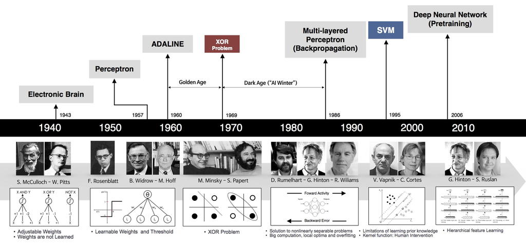

[State of the R](https://stateofther.github.io/)

## Les débuts (1940-)

### L'ordinateur apprenant : Alan Turing

- ‘Computing Machinery and Intelligence’ présente le ‘test de Turing’

### Le neurone artificiel : W. Pitts and W. McCulloch

- unité logique minimale
- Warren McCulloch et Walter Pitts propose de créer une machine de Turing neuronale

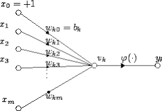

\[y_k = \varphi \left( \sum_{j=0}^m w_{kj} x_j \right)\]

[State of the R](https://stateofther.github.io/)

## Le perceptron de Frank Rosenblatt (1957)

Frank Rosenblatt's Mark I Perceptron at the Cornell Aeronautical Laboratory, Buffalo, New York, circa 1960

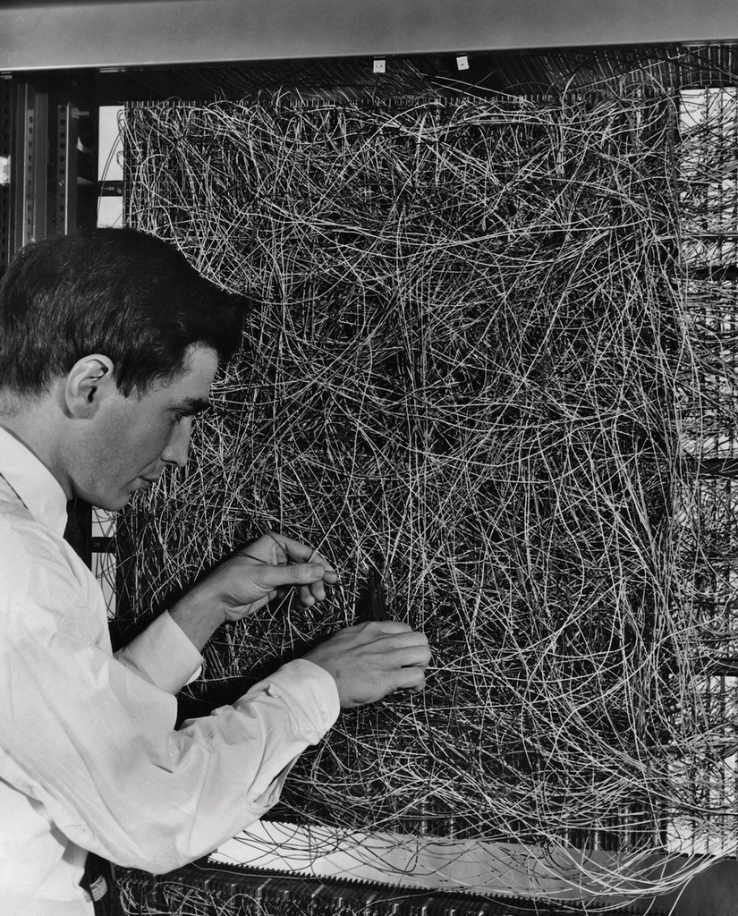

> [The perceptron] is the embryo of an electronic computer that [the Navy] expects will be able to walk, talk, see, write, reproduce itself and be conscious of its existence. Rosenblatt

[State of the R](https://stateofther.github.io/)

## La mort du perceptron (1969)

> Dans ''Perceptrons: an introduction to computational geometry'' remarquent qu'un séparateur linéaire ne peut implémenter le XOR… imparable et mortelle remarque. Marvin Minsky et Seymour Papert

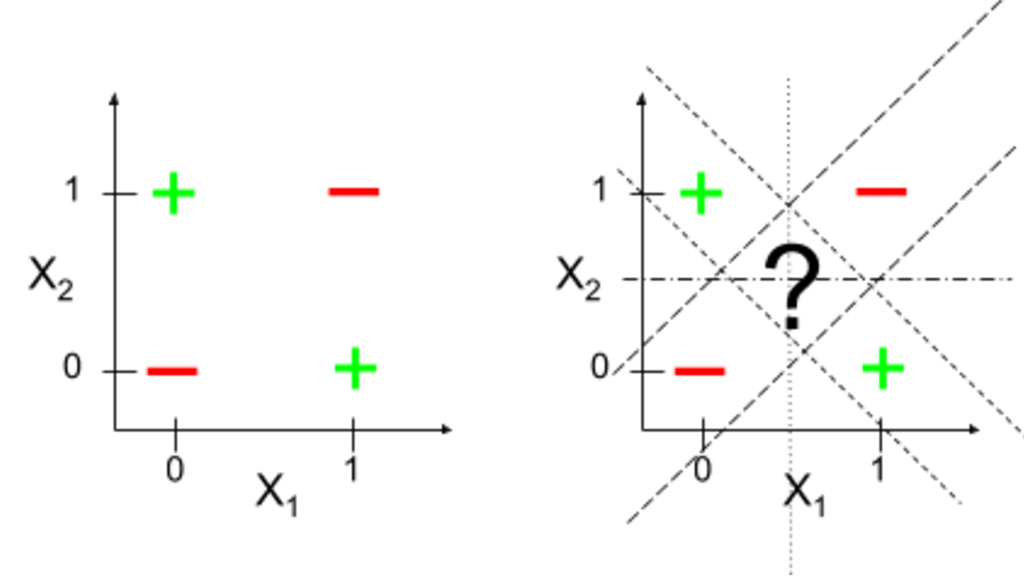

[State of the R](https://stateofther.github.io/)

## Le rétro-propagation du gradient et les réseaux de neurones multi-couches

### Le perceptron multicouches

- **Geoff Hinton** (arrière-arrière-petit-fils de George Bool) termine son doctorat sur les réseaux de neurones en 1978
- En 1986, avec **David Rumelhart** ils publient un article sur les réseaux de neurones avec de nombreuses couches cachées

### Problème d'optimisation complexe

- nombreux paramètres
- critère mal défini

### Descente de gradient par rétropropagation

- fonction composée à optimiser
- fonction d'activation de chaque neurone continue et dérivable
- pas fixe

[State of the R](https://stateofther.github.io/)

## La concurrence des années 90

### Les machines à vecteurs de support

- **1963**, une idée deVladimir N. Vapnik et Alexey Ya. Chervonenkis
- **1993**, le truc du noyau et un problème d'optimisation décrit Boser, Guyon et Vapnik

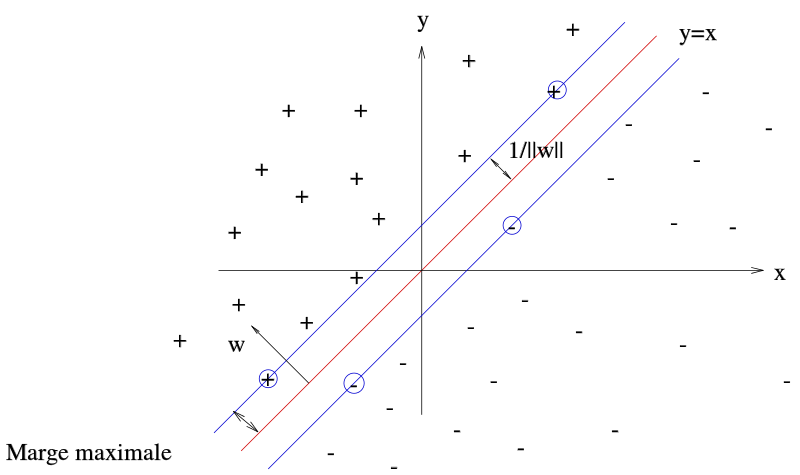

[State of the R](https://stateofther.github.io/)

## Renaissance (2006 ?)

### Apprentissage profond (Hinton 2006)

- former un simple modèle non supervisé à 2 couches,
- geler tous les paramètres, de coller une nouvelle couche sur le dessus et de former uniquement les paramètres de la nouvelle couche.

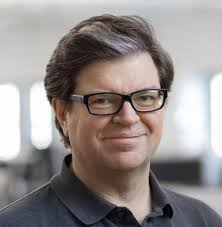

### Succés en traitement d'image

- Réseau convolutif de Y. Lecun

> **Deep Learning Hypothesis**: The success of deep learning is largely a success of engineering. ??

[State of the R](https://stateofther.github.io/)

## Les acteurs

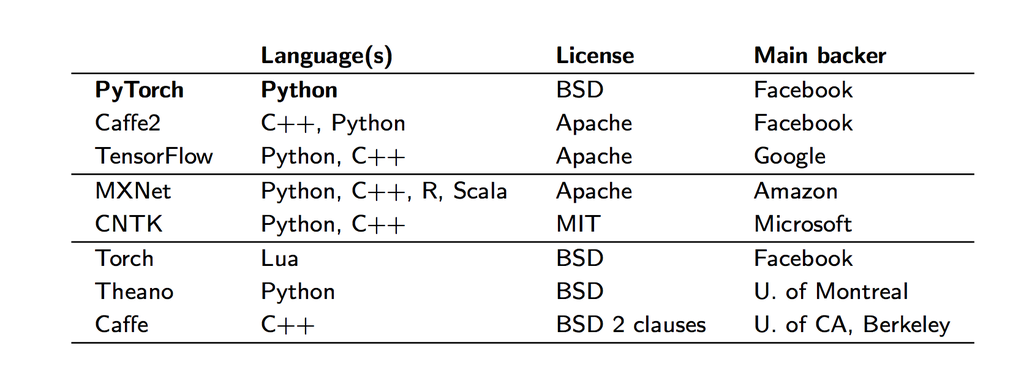

[State of the R](https://stateofther.github.io/)

## Quelques liens

- Cours du collège de France de Y. Lecun https://www.college-de-france.fr/site/yann-lecun/inaugural-lecture-2016-02-04-18h00.htm
- https://beamandrew.github.io/deeplearning/2017/02/23/deep_learning_101_part1.html
- https://www.import.io/post/history-of-deep-learning/

[State of the R](https://stateofther.github.io/)